# Classification of Igneous Rocks

Dr. Ahmad Redaa

2024-09-25

# Bases of Igneous Rock Classification

## Issues with Terminology

- **Felsic/Mafic**:
  - Terms are based on mineral composition but often used based on color.
  - Example: Dark-colored quartz and feldspars are still felsic, leading to confusion.
- **Acidic/Basic**:
  - Terms derived from outdated concepts (silicic acid in solution).
  - Not accurate for describing magmas or modern petrology.
  - Basic rocks are generally mafic, but chemical content should take precedence over color.

# Terms in Literature

- **Mafic and Felsic**:
  - Applied to both rocks and magmas.
  - Considered appropriate despite being mineral-based.
- **Basic and Acidic**:
  - Applied to magmas and based on chemical composition rather than mineralogy.
- **Other terms**:
  - Descriptive terms like “basaltic magma” and “andesitic magma” name the magma based on its solidified equivalent.
  - Use of precise chemical descriptions (e.g., “silicic” or “alkaline”) for unusual concentrations of certain components.
- Terminological inconsistencies can lead to confusion in the classification and description of igneous rocks and magmas.
- While terms like “felsic” and “mafic” dominate North American literature, British geologists prefer “basic” and “acidic,” focusing more on chemical composition.
- A balance between mineral-based and chemical-based descriptions is essential for clarity in igneous rock classification.

# The IUGS Classification

- This Classification was developed by the International Union of Geological Sciences (IUGS) to standardize igneous rock nomenclature.
- The IUGS system requires that we determine the mineral components of a rock and plot the percentages of three of those components on appropriate triangular diagrams to determine the proper name.

# Plotting on a Triangular Diagram

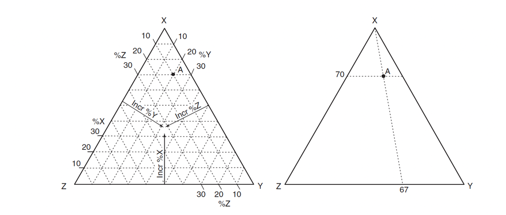

Source: [Winter, J. (2014)](https://www.whitman.edu/geology/winter/Winter_Principles%20of%20Igneous%20and%20Metamorphic%20Petrology%20by%20JOHN%20D.%20WINTER-1.pdf)

## Steps to Plot 70% X, 20% Y, and 10% Z

### 1. Understand the Axes of the Triangular Diagram

- Each apex represents 100% of a component:
  - **X** at the top apex.
  - **Y** at the bottom right.
  - **Z** at the bottom left.
- Percentages decrease from each apex to the base opposite the apex.
  - The sum of X, Y, and Z must equal 100%.

### 2. Plot the 70% X Value

- Find the **X-axis**:
  - 70% X is represented by counting 7 divisions (70%) from the Y–Z base toward the X apex.

### 3. Plot the 20% Y Value

- Move along the **Y-Z base**:
  - Starting from the **Z apex**, move 67% of the way toward **Y** (because Y/(Y + Z) = 20/30 = 67%).

### 4. Locate the Point

- Draw a line from the 67% Y-Z point toward the X apex.
- Mark the point where this line intersects the **70% X line**.

### 5. Verify the Z Value

- The point should also align with **10% Z** by counting up 1 division from the X–Y base toward the Z apex.
- The intersection of these lines represents **70% X, 20% Y, and 10% Z**.

## Final Result

- The point A representing **70% X, 20% Y, and 10% Z** is plotted where the **70% X** line, the **10% Z** line, and the **20% Y** line intersect.

# Classification Based on Mineral Content

- For most igneous rocks: **Q + P + A** (Quartz, Plagioclase, Alkali Feldspar).
- If feldspathoids are present: **F + P + A** (Feldspathoids, Plagioclase, Alkali Feldspar).

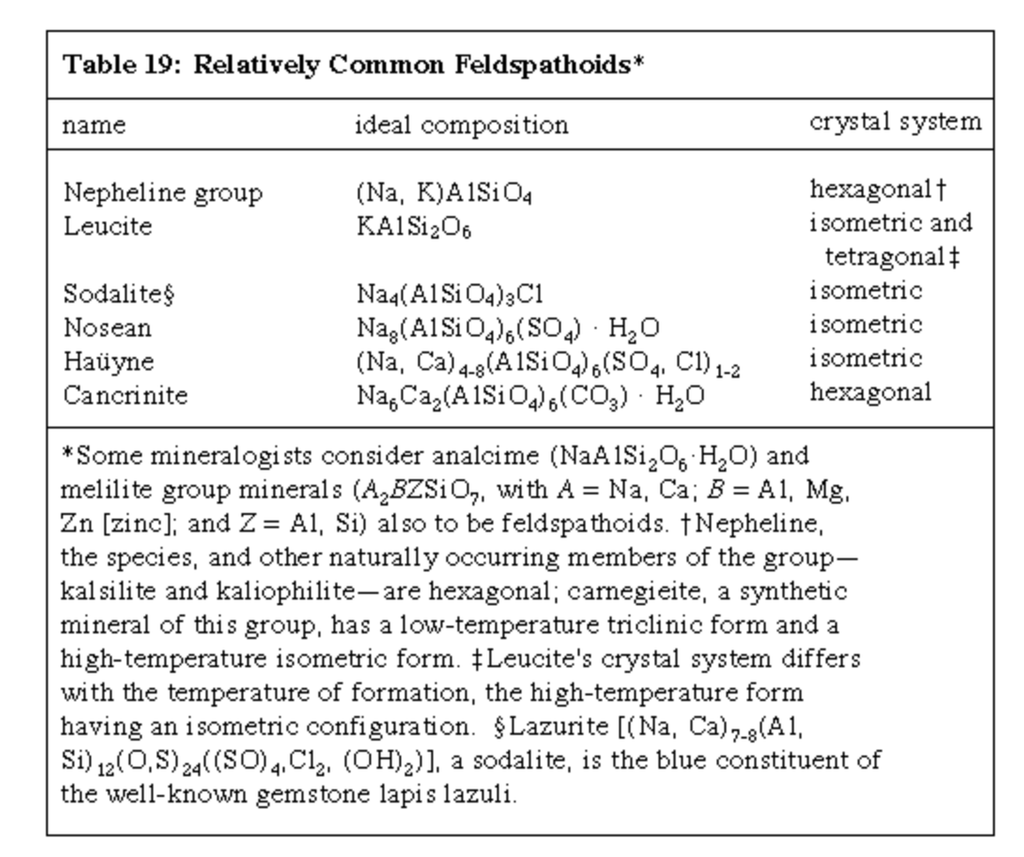

Source: [https://www.britannica.com](https://www.britannica.com/science/feldspathoid)

# Classification of The Plutonic Igneous Rocks

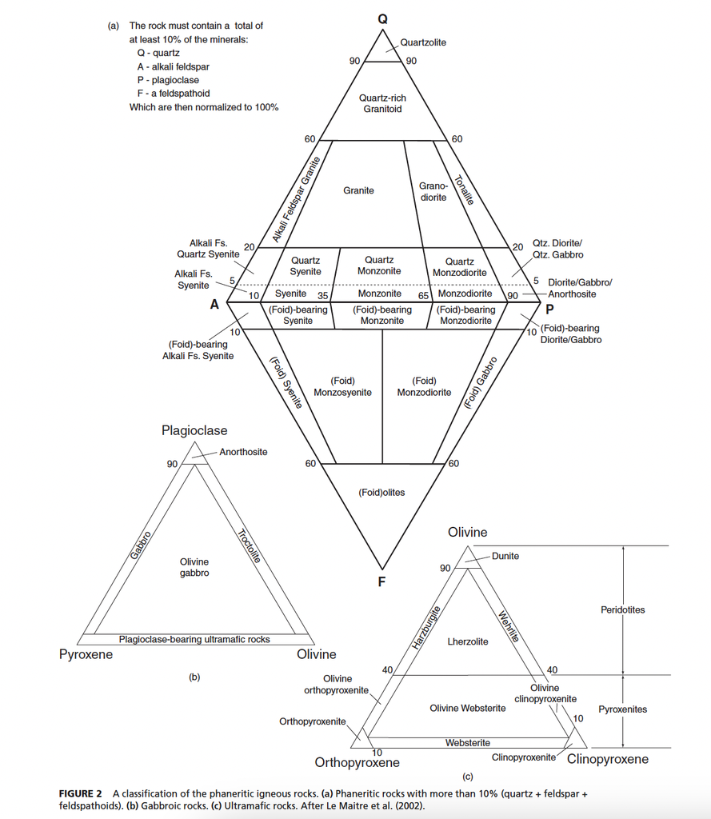

Source: [Winter, J. (2014)](https://www.whitman.edu/geology/winter/Winter_Principles%20of%20Igneous%20and%20Metamorphic%20Petrology%20by%20JOHN%20D.%20WINTER-1.pdf)

# Classification of Volcanic Rocks

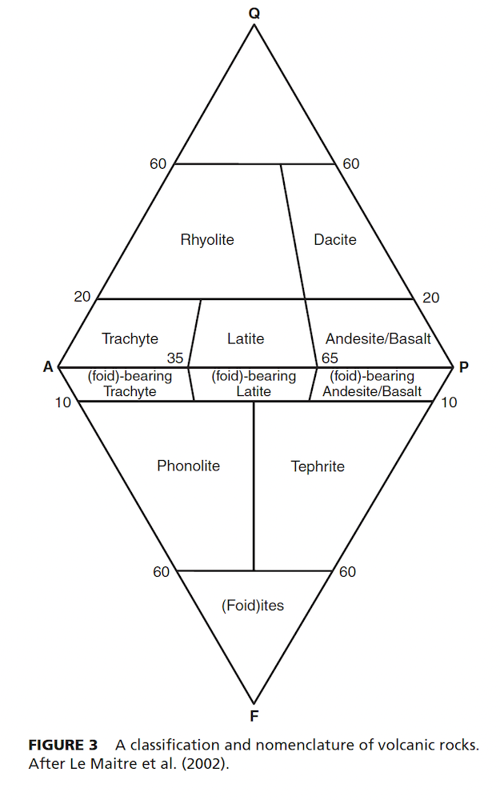

Source: [Winter, J. (2014)](https://www.whitman.edu/geology/winter/Winter_Principles%20of%20Igneous%20and%20Metamorphic%20Petrology%20by%20JOHN%20D.%20WINTER-1.pdf)

# Chemical Classification of Volcanic Rocks

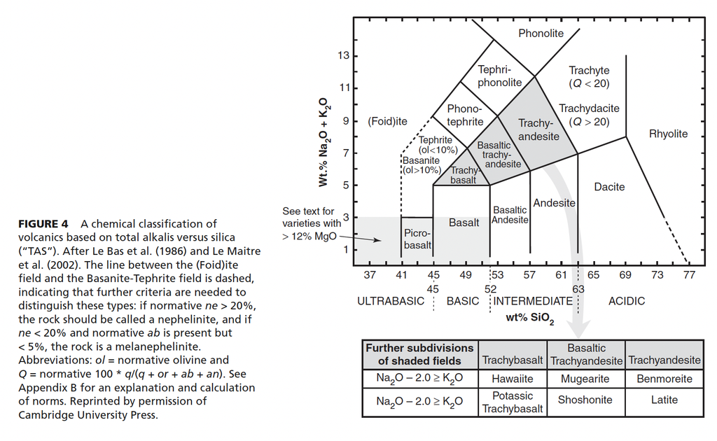

Source: [Winter, J. (2014)](https://www.whitman.edu/geology/winter/Winter_Principles%20of%20Igneous%20and%20Metamorphic%20Petrology%20by%20JOHN%20D.%20WINTER-1.pdf)

# Chemical Classification

1. Silica Saturation
2. Alumina (Al2O3) Saturation
3. Alkaline/Subalkaline Rocks

# Silica Saturation

If a magma is **oversaturated** with respect to silica, then a silica mineral such as quartz, cristobalite, tridymite, or coesite should precipitate from the magma and be present in the rock. On the other hand, if a magma is **undersaturated** with respect to silica, a silica mineral will not precipitate and thus will not be present in the rock. This concept divides rocks into three categories:

### 1. Silica Undersaturated Rocks

These rocks contain minerals that, in general, do not coexist with quartz. Such minerals include:

- **Nepheline** (NaAlSiO₄)
- **Leucite** (KAlSi₂O₆)
- **Forsteritic Olivine** (Mg₂SiO₄)
- **Sodalite** (3NaAlSiO₄ · NaCl)
- **Nosean** (6NaAlSiO₄ · Na₂SO₄)
- **Haüyne** (6NaAlSiO₄ · (Na₂,Ca)SO₄)
- **Perovskite** (CaTiO₃)
- **Melanite** (Ca₂Fe³⁺Si₃O₁₂)
- **Melilite** ((Ca,Na)₂(Mg,Fe²⁺,Al,Si)₃O₇)

These minerals indicate a silica-undersaturated rock. When calculating a CIPW norm, silica-undersaturated rocks will contain normative nepheline and/or leucite.

### Note

The **CIPW Norm** (Cross, Iddings, Pirsson, Washington Norm) is a method used to calculate the idealized mineral composition of an igneous rock based on its chemical analysis. It provides a way to standardize and classify rocks by computing a theoretical set of minerals (the norm) that would form from a complete crystallization of the rock’s magma under dry conditions at low pressure.

### 2. Silica Oversaturated Rocks

These rocks can be identified as those that do not contain any of the minerals listed above. When calculated in the CIPW norm, silica-oversaturated rocks will contain normative quartz.

### 3. Silica Saturated Rocks

# Alumina (Al₂O₃) Saturation

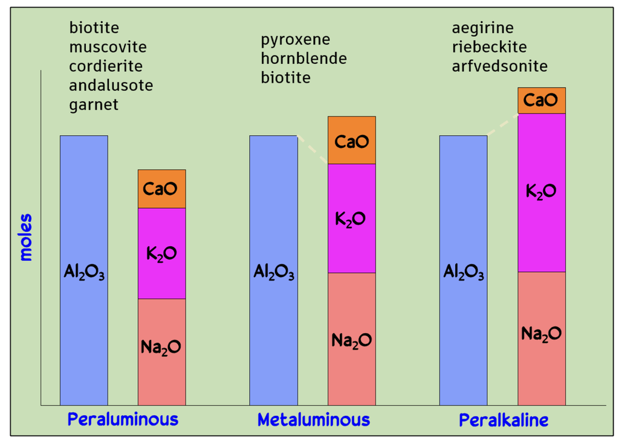

Source: [geologyhub.com](https://geologyhub.com/granite-rock-classification-and-origin)

### 1. Peraluminous Rocks

- **Condition**: Alumina (Al₂O₃) exceeds the amount required to form feldspars.
- **Chemical Expression**: Al₂O₃ > (CaO + Na₂O + K₂O)
- **Expected Minerals**: Al₂O₃-rich minerals such as muscovite, corundum, topaz, kyanite, andalusite, or sillimanite.
- **CIPW Norm**: Contains corundum (Al₂O₃) and lacks diopside.

### 2. Metaluminous Rocks

- **Condition**: Alumina is balanced with alkali and alkaline earth oxides.
- **Chemical Expression**: Al₂O₃ < (CaO + Na₂O + K₂O) and Al₂O₃ > (Na₂O + K₂O)
- **Expected Minerals**: Lack Al₂O₃-rich minerals, sodic pyroxenes, and amphiboles.
- **Common Examples**: Most common igneous rocks like diorite, gabbro.

### 3. Peralkaline Rocks

- **Condition**: Excess of alkalies (Na₂O + K₂O), undersaturated in alumina.
- **Chemical Expression**: Al₂O₃ < (Na₂O + K₂O)
- **Expected Minerals**: Na-rich minerals like aegerine, riebeckite, arfvedsonite, or aenigmatite.
- **CIPW Norm**: Contains acmite (NaFe³⁺Si₂O₆) and/or sodium metasilicate (Na₂SiO₃).

# Alkaline vs Subalkaline Rocks

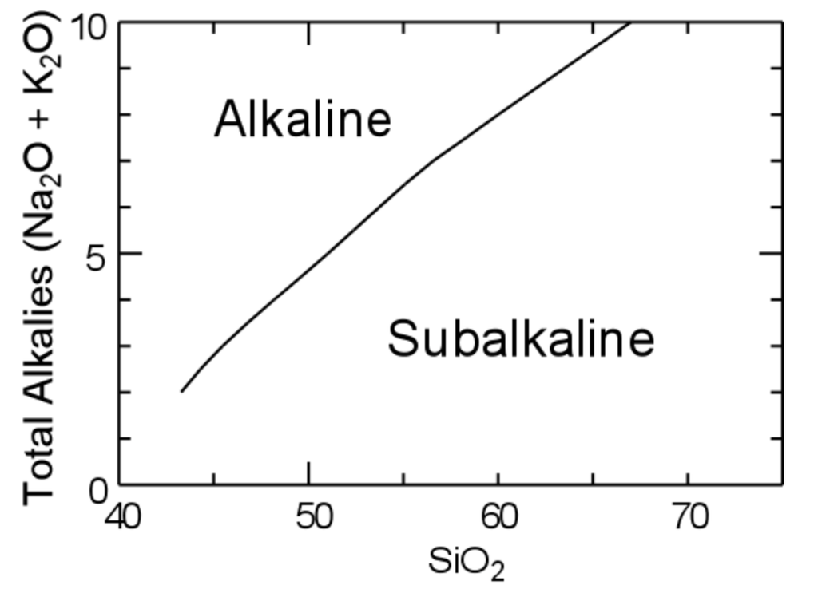

Source: [www2.tulane.edu](https://www2.tulane.edu/~sanelson/eens212/igrockclassif.htm)

Rocks can be classified as **alkaline** or **subalkaline** based on their alkali content relative to silica, using an alkali vs. silica diagram.

### 1. Alkaline Rocks

- **Characteristics**: High in alkali (Na₂O + K₂O) compared to silica.
- **Silica Saturation**: Often silica undersaturated, but not always peralkaline.
- **Relation to Peralkaline**: While peralkaline rocks are generally alkaline, not all alkaline rocks are peralkaline.

### 2. Subalkaline Rocks

- **Characteristics**: Lower in alkali content relative to silica.
- **Silica Saturation**: Tend to be more silica-saturated.

> **Note**: Very alkaline rocks, which plot well above the dividing line in the alkali vs. silica diagram, are usually silica undersaturated.

# Classification of Pyroclastic Rocks

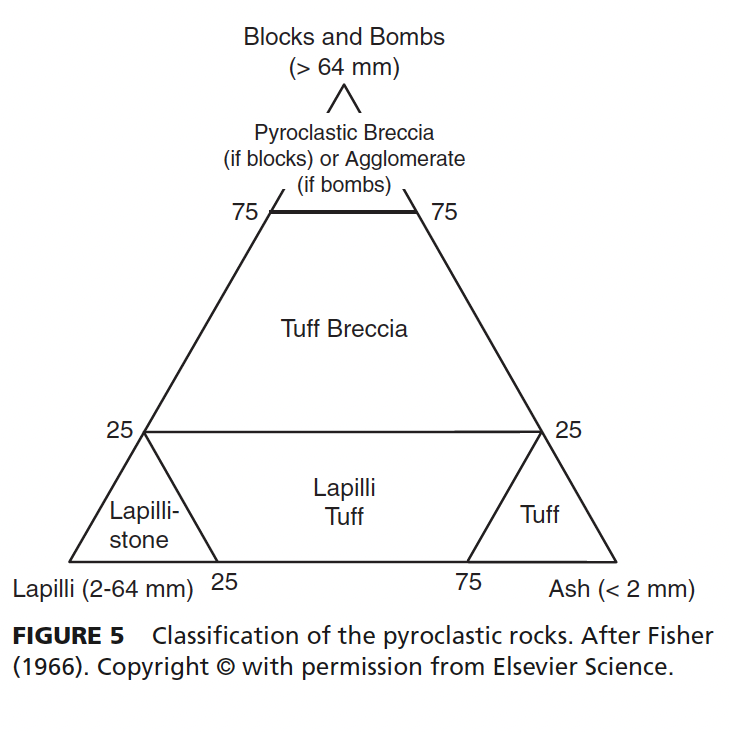

Source: [Winter, J. (2014)](https://www.whitman.edu/geology/winter/Winter_Principles%20of%20Igneous%20and%20Metamorphic%20Petrology%20by%20JOHN%20D.%20WINTER-1.pdf)

- **Pyroclastic Rocks**: Formed from volcanic fragments (pyroclasts) during explosive eruptions.
- Classified based on:
  - **Type of fragmental material**.
  - **Size of the fragments**.
  - **Chemical or modal composition** (if possible, when impurities are minimal).

## Fragment Size Classification

- **> 64 mm**: Bombs (if molten during fragmentation—thus typically rounded/blobby, flattened, or stretched) or Blocks (if not molten during fragmentation—thus typically angular or broken).
- **2–64 mm**: Lapilli.
- **< 2 mm**: Ash.

## Key IUGS Requirements

- A true pyroclastic rock must contain at least **75% pyroclasts**.
  - Pyroclasts can include individual crystals, glass, or rock fragments.
  - Crystals are referred to as **crystal fragments**, not phenocrysts.

## Types of Pyroclastic Rocks

- **Tuffs**: Classified based on fragment type.
  - **Coarse Ash Tuff**: Fragments 1/16 mm to 2 mm.
  - **Fine Ash Tuff (Dust Tuff)**: Fragments < 1/16 mm.
  - **Lithic Tuff**: Dominated by rock fragments.
  - **Vitric Tuff**: Dominated by pumice/glass fragments.
  - **Crystal Tuff**: Dominated by crystal fragments.
- **Example**: *Rhyolitic Lapilli Tuff* - A pyroclastic rock dominated by lapilli-sized fragments with a rhyolitic composition.

## Mixed Pyroclastic and Sedimentary Rocks

- **Tuffite**: Contains both pyroclastic and sedimentary clastic material (epiclasts).
  - Can be further classified (e.g., *Tuffaceous Sandstone*).
- **Epivolcaniclastics**: Secondary deposits, not directly from eruptions (e.g., volcanic mudflows or reworked epiclasts).

## Special Types of Pyroclastic Deposits

- **Aquagene Tuff**: Waterborne ash accumulation, either from subaqueous eruptions or reworked by water.
- **Hyalotuff/Hyaloclastite**: Created when magma is shattered upon contact with water.

# Other Ignous Rocks

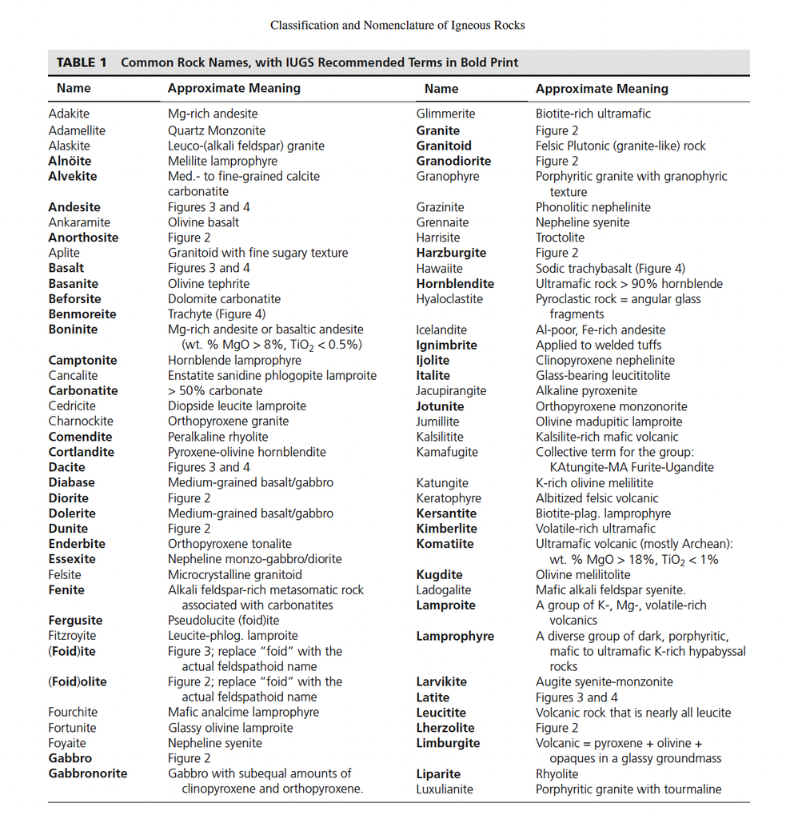

Source: [Winter, J. (2014)](https://www.whitman.edu/geology/winter/Winter_Principles%20of%20Igneous%20and%20Metamorphic%20Petrology%20by%20JOHN%20D.%20WINTER-1.pdf)